# Final Project

## A Look into Age and Performance in the Premier League

### Soc 223

## Introduction

As we age, playing sports at a top-notch level becomes tougher. Our bodies change, and what used to be easy becomes a bit more challenging. This can have an effect on athlete’s stats and results as they grow older, but how does this relate at the highest level?

I wanted to examine the relationship between age and a player’s success in the Premier League, the biggest and best professional football league in the world. My hypothesis is that as a player gets older, they slowly start to increase in their performance, until reaching a peak, and then their performance starts to significantly decrease.

My data consists of player information and statistics from all clubs in the Premier League from the 2020 season. This includes a player’s name, position, age, appearances, goals, wins, losses, tackles, shots, etc.

## Data

Let’s load in some packages.

Now, I will load in the data set of player statistics from the 2020 Premier League season.

First, lets look at age across the Premier League

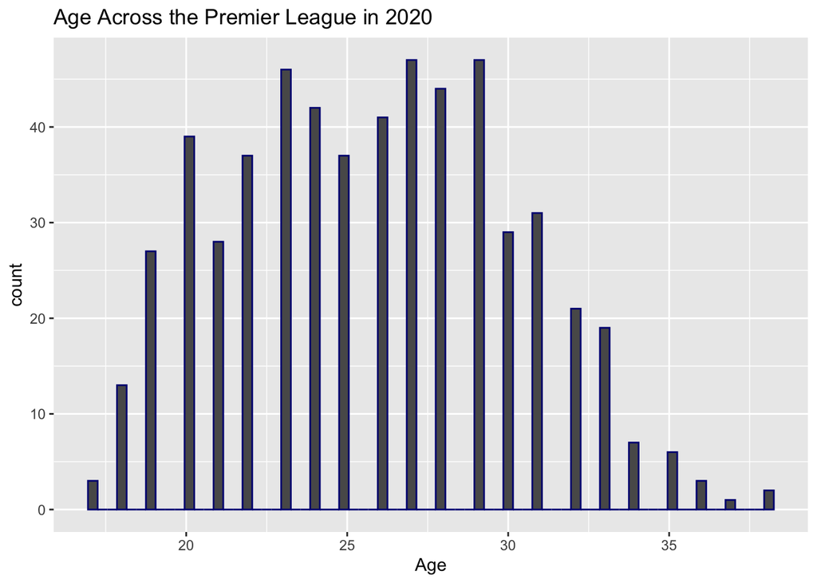

Let’s also take a look at the minimum age value, maximum age value, as well as the mean age value and standard deviation.

| mean | std_dev | min | max |
| --- | --- | --- | --- |
| 25.79 | 4.38 | 17 | 38 |

## The Success Metric

The purpose of my project is to see the relationship between age and “success” from players in the Premier League. But how will I determine how an *individual* is successful in the premier league?

The success metric I have set forth is determined by taking a bunch of key variables from the Premier League data-set and adding the values together into one total score. I determined what variables I believed were most important in the game of football, as well as making sure to include a balance of more offensive traits and defensive traits to cater towards all field players. The variables being used will be:

*Goals*

*Assists*

*Tackles*

*Interceptions*

Unfortunately, due to my project’s goal and limitations, we will be removing goalkeepers from the data-set, as they will have low values in the different variables for success and ultimately will have a low score on the success metric. Let’s filter out the goalkeeper position.

## Success Metric

Now we can begin making the success metric.

It’s also important that I provide the log of the success metric to provide a more “normalized” distribution and prevent the skewness of a measurement variable.

Now we can compare the difference between the success metric and the “log-success” metric.

```
# A tibble: 423 × 1
   success_metric
            <dbl>
 1            447
 2             35
 3            115
 4            104
 5            403
 6            513
 7            604
 8            197
 9              5
10            323
# ℹ 413 more rows
```

```
# A tibble: 423 × 1
   logsuccess_metric
               <dbl>
 1              6.10
 2              3.56
 3              4.74
 4              4.64
 5              6.00
 6              6.24
 7              6.40
 8              5.28
 9              1.61
10              5.78
# ℹ 413 more rows
```

Now, we are able to see every player’s (except goalkeepers) score on my success metric. Now, let’s view it by Name, Club, Position, and Age and graph both the base and log relationships.

```
# A tibble: 423 × 5
   success_metric Name               Club                     Position     Age
            <dbl> <chr>              <chr>                    <chr>      <dbl>
 1             10 Jarrad Branthwaite Everton                  Defender      18
 2             37 Mason Greenwood    Manchester-United        Forward       18
 3             54 Bukayo Saka        Arsenal                  Midfielder    19
 4             26 Gabriel Martinelli Arsenal                  Forward       19
 5             37 Tariq Lamptey      Brighton-and-Hove-Albion Defender      19
 6              8 Billy Gilmour      Chelsea                  Midfielder    19
 7             33 Callum Hudson-Odoi Chelsea                  Forward       19
 8             20 Anthony Gordon     Everton                  Forward       19
 9              5 Luke Thomas        Leicester-City           Defender      19
10             14 Neco Williams      Liverpool                Defender      19
# ℹ 413 more rows
```

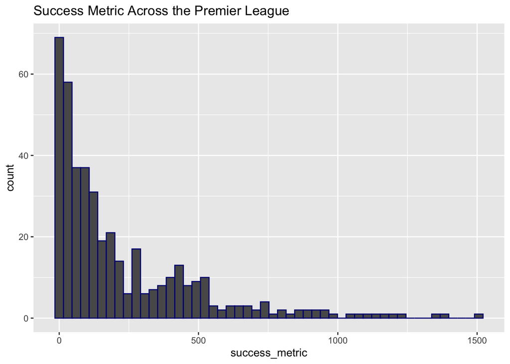

```
# A tibble: 423 × 5
   logsuccess_metric Name               Club                     Position    Age
               <dbl> <chr>              <chr>                    <chr>     <dbl>
 1              2.30 Jarrad Branthwaite Everton                  Defender     18
 2              3.61 Mason Greenwood    Manchester-United        Forward      18
 3              3.99 Bukayo Saka        Arsenal                  Midfield…    19
 4              3.26 Gabriel Martinelli Arsenal                  Forward      19
 5              3.61 Tariq Lamptey      Brighton-and-Hove-Albion Defender     19
 6              2.08 Billy Gilmour      Chelsea                  Midfield…    19
 7              3.50 Callum Hudson-Odoi Chelsea                  Forward      19
 8              3.00 Anthony Gordon     Everton                  Forward      19
 9              1.61 Luke Thomas        Leicester-City           Defender     19
10              2.64 Neco Williams      Liverpool                Defender     19
# ℹ 413 more rows
```

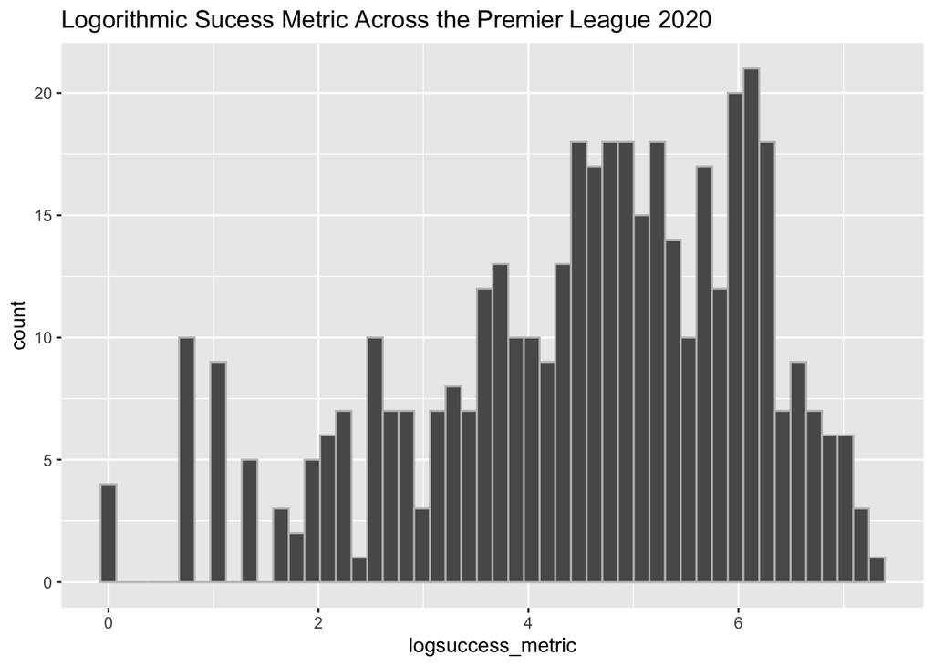

Looking at the two graphs, we can clearly see that Logarithmic Success Metric histogram provides a more appealing display of the relationship between age and success. This is due to its more normalized shape.

## Defenders

Let’s look at only defenders and their success metric scores.

```
# A tibble: 154 × 5
   logsuccess_metric Name               Club                     Position   Age
               <dbl> <chr>              <chr>                    <chr>    <dbl>
 1             2.30  Jarrad Branthwaite Everton                  Defender    18
 2             3.61  Tariq Lamptey      Brighton-and-Hove-Albion Defender    19
 3             1.61  Luke Thomas        Leicester-City           Defender    19
 4             2.64  Neco Williams      Liverpool                Defender    19
 5             3.18  Eric García        Manchester-City          Defender    19
 6             4.29  Reece James        Chelsea                  Defender    20
 7             3.64  Brandon Williams   Manchester-United        Defender    20
 8             0.693 Ethan Ampadu       Sheffield-United         Defender    20
 9             0.693 Jake Vokins        Southampton              Defender    20
10             2.56  Ben Johnson        West-Ham-United          Defender    20
# ℹ 144 more rows
```

| mean | std_dev | min | max |
| --- | --- | --- | --- |
| 4.82 | 1.59 | 0.69 | 7.21 |

## Midfielders

Let’s look at only midfielders and their success metric scores.

```
# A tibble: 173 × 5
   logsuccess_metric Name              Club              Position     Age
               <dbl> <chr>             <chr>             <chr>      <dbl>
 1             3.99  Bukayo Saka       Arsenal           Midfielder    19
 2             2.08  Billy Gilmour     Chelsea           Midfielder    19
 3             1.95  Curtis Jones      Liverpool         Midfielder    19
 4             0.693 Emile Smith Rowe  Arsenal           Midfielder    20
 5             4.96  Dwight McNeil     Burnley           Midfielder    20
 6             0     Jamie Shackleton  Leeds-United      Midfielder    20
 7             3.81  Phil Foden        Manchester-City   Midfielder    20
 8             2.30  Matthew Longstaff Newcastle-United  Midfielder    20
 9             2.89  William Smallbone Southampton       Midfielder    20
10             4.08  Ryan Sessegnon    Tottenham-Hotspur Midfielder    20
# ℹ 163 more rows
```

| mean | std_dev | min | max |
| --- | --- | --- | --- |
| 4.45 | 1.7 | 0 | 7.32 |

Out of the midfielders, the mean or average of the success metric was 4.45 with a standard deviation of 1.7. The lowest value was 0 and the highest value was 7.32.

## Forwards

Let’s look at only forwards and their success metric scores.

```
# A tibble: 96 × 5
   logsuccess_metric Name               Club                     Position   Age
               <dbl> <chr>              <chr>                    <chr>    <dbl>
 1              3.61 Mason Greenwood    Manchester-United        Forward     18
 2              3.26 Gabriel Martinelli Arsenal                  Forward     19
 3              3.50 Callum Hudson-Odoi Chelsea                  Forward     19
 4              3.00 Anthony Gordon     Everton                  Forward     19
 5              3.09 Reiss Nelson       Arsenal                  Forward     20
 6              2.56 Aaron Connolly     Brighton-and-Hove-Albion Forward     20
 7              2.71 Moise Kean         Everton                  Forward     20
 8              1.39 Ben Woodburn       Liverpool                Forward     20
 9              3.09 Michael Obafemi    Southampton              Forward     20
10              3.30 Pedro Neto         Wolverhampton-Wanderers  Forward     20
# ℹ 86 more rows
```

| mean | std_dev | min | max |
| --- | --- | --- | --- |
| 4.12 | 1.45 | 0 | 6.26 |

Out of the forwards, the mean or average of the success metric was 4.12 with a standard deviation of 1.45. The lowest value was 0 and the highest value was 6.26.

## Position Results

Surprisingly, the forward position had the least average value and smallest maximum value. However, it does make sense that the midfielder position had the highest maximum score. The way a midfielder operates is in their name, the middle of the field. Therefore, they have a lot of involvement on both sides of the ball (offense and defense).

## Linear Regression

Let’s look at a scatter plot of the relationship between our success metric and age.

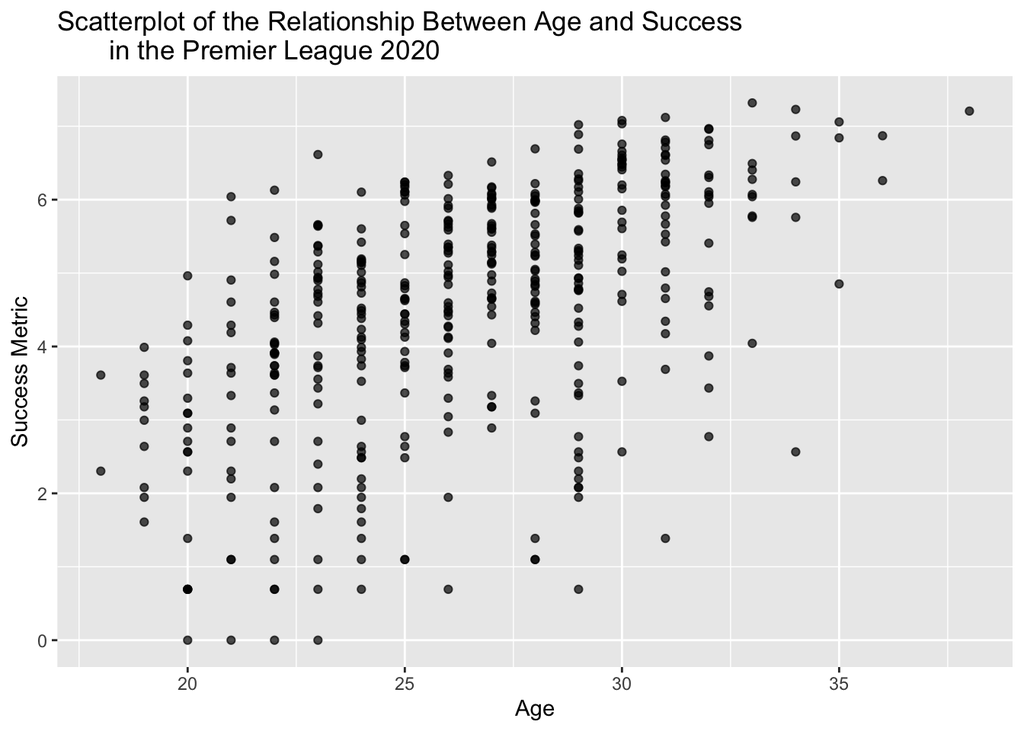

Next, let’s plot a regression to see our relationship.

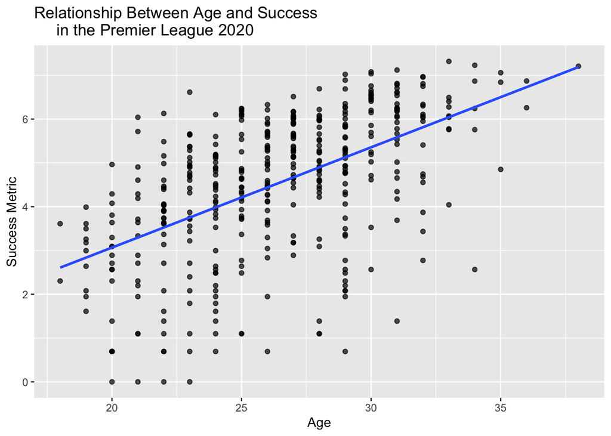

| term | estimate | std_error | statistic | p_value | lower_ci | upper_ci |
| --- | --- | --- | --- | --- | --- | --- |
| intercept | -1.51 | 0.46 | -3.29 | 0 | -2.42 | -0.61 |
| Age | 0.23 | 0.02 | 13.24 | 0 | 0.20 | 0.26 |

| mean_success |
| --- |
| 4.51 |

What’s interesting is the graph. The graph shows a linear relationship between success and age in the Premier League, instead of a more parabolic shape. Why is this the case? Shouldn’t as you get older, your stats, performance, and overall “success” decrease?

## Discussion/Conclusion

We see that as age increases, player’s only become more successful in the Premier League. However, based on the data and results shown, it appears that the Premier League doesn’t show that the relationship between age and success metric is parabolic or squared. This is maybe because the premier league is top tier. Players that age older get removed from the premier league, so we don’t get to see them drop off. This is why we see great players like Messi, go to lower leagues such as the MLS (shame to say). Therefore, it’s safe to assume that when players reach around the 35 year old mark, they transfer out of the Premier League and into different, ‘lower-level’ leagues.

## Future Directions and Final Thoughts

A further study of my project would be analyzing how different the “success metric” would be if I changed the variables (categories that made the success metric) and how it affected the average, min, max, of the different positions.

It’d also be important to look at other leagues across the globe, specifically “lower-level” leagues and see how age compares to players’ success.

It’s also worth noting that although the logarithmic data presents better visuals of the data, it may make more sense to read success-metric the data in it’s base form. This is because it’s easy to picture in ones head the number of goals, assists, tackles etc. as a whole number.